# de Jong et al (2018)

# Shoot branching plasticity depends on shoot genotype

The code in this document has the analysis of the RT-qPCR data for Nitrate- responsive genes and analysis of grafting experiments.

```r
library(tidyverse)
library(patchwork)

# Change ggplot2 default aesthetics
theme_set(theme_classic() +
            theme(panel.grid = element_blank(),
                  text = element_text(size = 8),
                  plot.title = element_text(hjust = -0.07, size = 10, face = "bold",
                                            margin = margin(t = -5, b = 1)),
                  plot.subtitle = element_text(size = 10, hjust = 0.5)))
```

## RT-qPCR analysis

We present the qPCR results as as the fold-change between treatment and control nitrate conditions. We use the $\Delta\Delta Cp$ method of [Livak & Schmittgen 2001](http://ac.els-cdn.com/S1046202301912629/1-s2.0-S1046202301912629-main.pdf?_tid=f6bbac12-2995-11e7-a6b3-00000aacb362&acdnat=1493111152_62fdd597373da762183aef1acc581a7e).

The approach is similar to what is illustrated in Fig. 2 of that paper. In summary, we do the following steps:

- For each gene calculate the mean Cp across the technical replicates
- For each sample calculate mean Cp for the two reference genes
- Normalise the expression of each gene by $\Delta Cp = Cp_{target} - Cp_{reference}$
- Calculate gene relative expression as $2^{-\Delta Cp}$

The fold change is then calculated in relation to the average $\Delta Cp$ of control samples:

- Separate table into treatment and control conditions
- In the control table, calculate mean Cp for each gene
- Merge this new table with the treatment table
- Calculate second delta-Cp as $\Delta\Delta Cp = \Delta Cp_{treatment} - \Delta Cp_{control}$
- Calculate fold change as $2^{-\Delta\Delta Cp}$

### Read Data

First we read and tidy the data:

```r
# Read data
qpcr <- read_csv("../../data/qpcr/nitrate_response_qpcr.csv") %>%
  select(-line) %>%
  rename(line = line_name) %>%
  mutate(line = factor(line, levels = c("Col-0", "MAGIC.11", "Hi-0", "Sha", "MAGIC.345", "Rsch-4", "Tsu-0")))
#gene = factor(gene) %>% relevel("GSR1")
```

### Normalise expression values

1. calculate the average across three technical replicates for each sample.

(Note: see this post for discussion between arithmetic and geometric means: https://www.researchgate.net/post/How_to_analyze_a_qPCR_with_2_or_3_housekeeping_genes)

```r
# Calculate average of technical replicates
qpcr_means <- qpcr %>%
  group_by(sample_nr, gene, rep, line, line_type, nitrate) %>%
  summarise(Cp_mean = mean(Cp, na.rm = TRUE)) %>%
  ungroup()
```

2. calculate the average for the two reference genes:

```r
# Calculate the mean expression of the two reference genes
qpcr_means <- qpcr_means %>%
  mutate(gene = ifelse(gene %in% c("APX3", "ubc9"), "reference", gene)) %>%
  group_by_at(vars(-Cp_mean)) %>%
  summarise(Cp_mean = mean(Cp_mean)) %>%
  ungroup()
```

3. calculate the first delta-Cp: $\Delta Cp = Cp_{target} - Cp_{reference}$

```r
# Add Cp of reference genes as a new column and calculate dCp
dcp <- qpcr_means %>%
  group_by(sample_nr) %>%
  mutate(Cp_ref = Cp_mean[gene == "reference"],
         dCp = Cp_mean - Cp_ref) %>%
  ungroup() %>%
  filter(gene != "reference") %>%
  rename(Cp_target = Cp_mean)
```

4. calculate average Cp of each gene in the control condition

```r
# Calculate the mean Cp in control samples per gene and genotype
dcp <- dcp %>%
  group_by(line, gene) %>%
  mutate(Cp_target_control = mean(Cp_target[nitrate == "control"]),
         Cp_ref_control = mean(Cp_ref[nitrate == "control"])) %>%
  ungroup()
```

5. calculate the delta-delta-Cp:

```r
# Calculate ddCp, the fold-change
# also relevel gene to ensure GSR1 appears first in the plots (as it's the only downregulated gene)
dcp <- dcp %>%
  mutate(ddCp = dCp - (Cp_target_control - Cp_ref_control),
         fold_change = 2^-ddCp,
         gene = factor(gene) %>% relevel("GSR1"))
```

### Fig 6

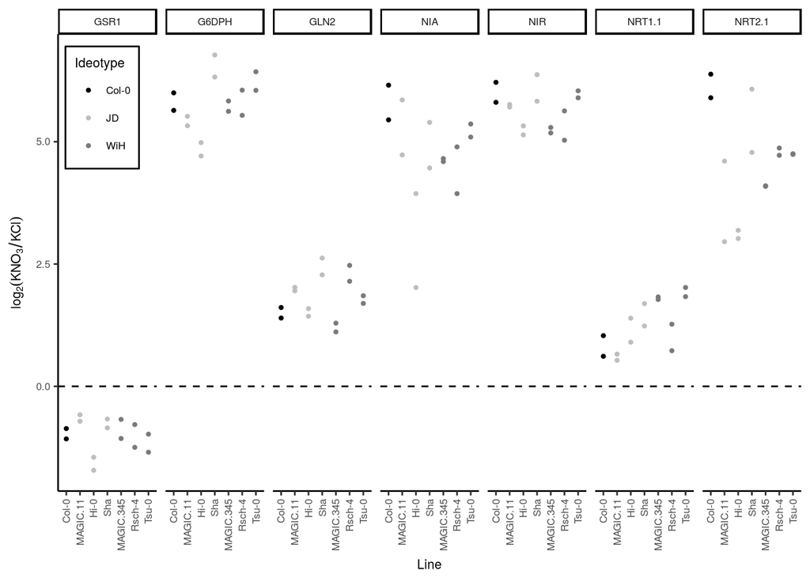

```r
# Plot log2(fold)
p1 <- dcp %>%
  filter(nitrate == "treat") %>%
  ggplot(aes(line, log2(fold_change), colour = line_type)) +
  geom_point(size = 0.8) +
  #geom_point(stat = "summary", fun.y = "mean", shape = "_", size = 4, colour = "black") +
  facet_grid( ~ gene, scales = "free_x") +
  geom_hline(yintercept = 0, linetype = "dashed") +
  scale_colour_manual(values = c("black", "grey", "gray48")) +
  labs(x = "Line", y = expression(log[2]("KNO"[3]/"KCl")),
       colour = "Ideotype") +
  theme(panel.grid = element_blank(),
        axis.text.x = element_text(angle = 90, hjust = 1, vjust = 0.5),
        legend.position = c(0, 1), legend.justification = c(-0.1, 1.1),
        legend.background = element_rect(color = "black", size = 0.5))

#pdf("./figures/figure6.pdf", width = 7, height = 2.5)
p1
```

```r
#dev.off()
```

It’s also worth to look at the relative expression of different samples, not just fold-change in relation to control:

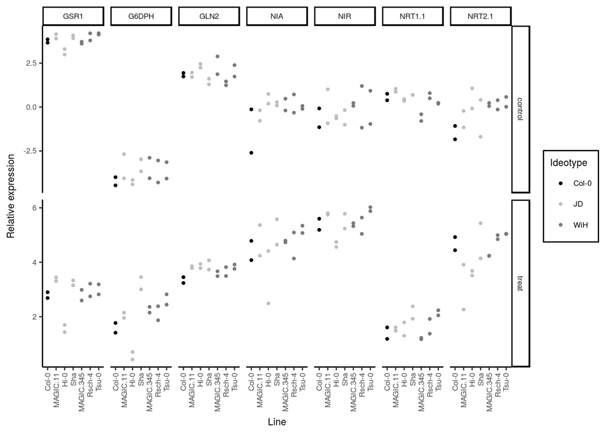

```r
dcp %>%
  ggplot(aes(line, (-dCp), colour = line_type)) +
  geom_point(size = 0.8) +
  facet_grid(nitrate ~ gene, scales = "free") +
  scale_colour_manual(values = c("black", "grey", "gray48")) +
  labs(x = "Line", y = "Relative expression",
       colour = "Ideotype") +
  theme(panel.grid = element_blank(),
        axis.text.x = element_text(angle = 90, hjust = 1, vjust = 0.5),
        legend.position = "right",
        legend.background = element_rect(color = "black", size = 0.5))
```

## Grafting analysis

These experiments were first performed in 2013 and then repeated in 2015. The data are analysed together (accounting for the potential variation between experiments).

### Read data

```r
graft <- read_csv("../../data/grafting/grafting_experiments.csv") %>%
  mutate(experiment = as.character(experiment))
```

```r
# Tidy data
## Remove plants that were too small
## Add a unique ID for each individual
## Make nitrate into a factor
## Order ID by the shoot type (convenient for consistent plotting)
graft <- graft %>%
  filter(small != "small" | is.na(small)) %>%
  mutate(id = paste(shoot_id, root_id, graft_type, sep = "\n"),
         nitrate = factor(nitrate, levels = c("HN", "LN")),
         type = ifelse(grepl("M11|M345", id), "MAGIC", "accession")) %>%
  mutate(id = reorder(as.factor(id), as.numeric(as.factor(paste0(shoot_type, graft_type)))))
```

This is the sample size distribution for each graft combination:

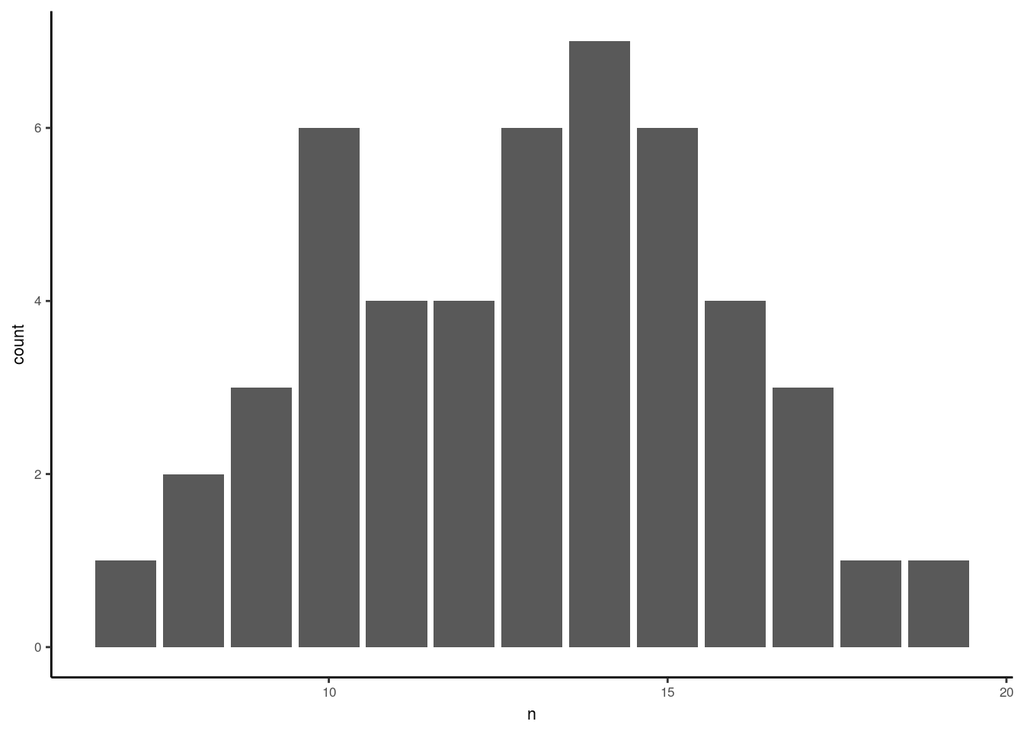

```r
# how many samples in each group
graft %>%
  count(experiment, id, nitrate) %>%
  ggplot(aes(n)) + geom_bar()
```

Because the sample sizes are different, we will test the effect of shoot and root ideotypes using linear mixed models (detailed below).

Here are the distributions of the two traits for each condition:

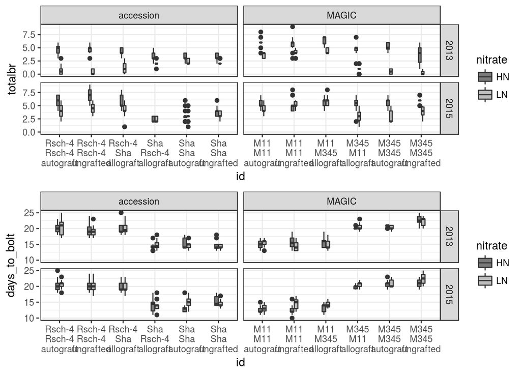

```r
p1 <- graft %>%
  mutate(id = gsub("_", "\n", id)) %>%
  ggplot(aes(id, totalbr, fill = nitrate)) +
  geom_boxplot() +
  facet_grid(experiment ~ type, scales = "free_x") +
  scale_fill_manual(values = c("gray48", "grey")) +
  theme_bw()

p2 <- graft %>%
  mutate(id = gsub("_", "\n", id)) %>%
  ggplot(aes(id, days_to_bolt, fill = nitrate)) +
  geom_boxplot(width = 1) +
  facet_grid(experiment ~ type, scales = "free_x") +
  scale_fill_manual(values = c("gray48", "grey")) +
  theme_bw()

p1 + p2 + plot_layout(ncol = 1)
```

### Fig 7

Here is the figure presented in the paper, which summarise things as means +/- CI:

[figure not shown]

```r
p1 <- graft %>%
  group_by(id, nitrate, experiment, type) %>%
  summarise(mean = mean(totalbr, na.rm = TRUE),
            sd = sd(totalbr, na.rm = TRUE),
            n = sum(!is.na(totalbr)),
            se = 1.96*sd/sqrt(n)) %>%
  mutate(id2 = paste(id, experiment)) %>%
  ggplot(aes(interaction(nitrate, id), mean, ymin = mean - se, ymax = mean + se, colour = nitrate)) +
  geom_line(aes(group = id2, linetype = experiment), colour = "black") +
  geom_point() +
  geom_errorbar(width = 0) +
  facet_grid( ~ type, scales = "free_x") +
  scale_colour_manual(values = c("black", "grey")) +
  theme(panel.grid = element_blank(), axis.text.x = element_text(size = 3)) +
  labs(x = "", y = "Total Branches", colour = "Nitrate")

p2 <- graft %>%
  group_by(id, nitrate, experiment, type) %>%
  summarise(mean = mean(days_to_bolt, na.rm = TRUE),
            sd = sd(days_to_bolt, na.rm = TRUE),
            n = sum(!is.na(days_to_bolt)),
            se = 1.96*sd/sqrt(n)) %>%
  mutate(id2 = paste(id, experiment)) %>%
  ggplot(aes(interaction(nitrate, id), mean, ymin = mean - se, ymax = mean + se, colour = nitrate)) +
  geom_line(aes(group = id2, linetype = experiment), colour = "black") +
  geom_point() +
  geom_errorbar(width = 0) +
  facet_grid( ~ type, scales = "free_x") +
  scale_colour_manual(values = c("black", "grey")) +
  theme(panel.grid = element_blank(), axis.text.x = element_text(size = 3)) +
  labs(x = "", y = "Days to Flowering", colour = "Nitrate") +
  ylim(0, 24)

#pdf("./figures/figure7.pdf", width = 7.5, height = 3.5)
p2 + p1 + plot_layout(ncol = 1)
```

```r
#dev.off()
```

### Effect of root and shoot ideotypes on branching

```r
# load library to fit mixed models
library(lme4)
library(broom)
source("./functions/plotLmmDiag.R") # function to plot some diagnostics from lme4 object
```

We use linear mixed models, partially because sample sizes are heterogenous across graft combinations (unbalanced design) but also to reduce degrees of freedom that would come from estimating intercepts and slopes for all different graft IDs:

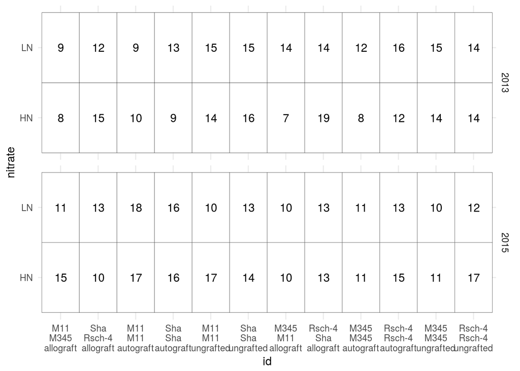

```r
graft %>%
  count(experiment, id, nitrate) %>%
  ggplot(aes(x = id, y = nitrate, label = n)) +
  geom_tile(fill = "white", colour = "black") +
  geom_text() +
  theme_minimal() +
  facet_grid(experiment ~ .)
```

Here is a summary of sample sizes (for figure legends):

```r
graft %>%
  count(experiment, id, nitrate) %>%
  group_by(experiment) %>%
  summarise(min(n), max(n), median(n))
```

```
## # A tibble: 2 x 4
##   experiment `min(n)` `max(n)` `median(n)`
##   <chr>         <dbl>    <dbl>       <dbl>
## 1 2013           7.00     19.0        14.0
## 2 2015          10.0      18.0        13.0
```

We use a random term to try and account for intra-class correlation of particular graft IDs.

We are primarily interested in understanding whether JD or WiH ideotype roots or shoots have an effect on branching and its plasticity. We therefore start with a full model that seems to make sense biologically, including terms for shoot and root ideotypes, as well as their interaction with nitrate.

We further add a random terms for the particular genotypes (`id`), with random slopes for nitrate. Although we’re not interested in its effect, experiment is added as a fixed effect (since there’s only two levels).

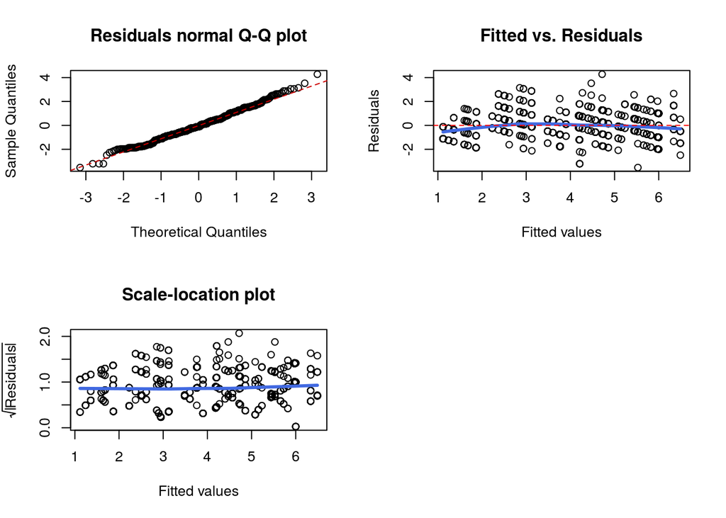

```r
# Fit the model by maximum-likelihood (necessary for likelihood-ratio tests later)
lmm1 <- lmer(totalbr ~ nitrate*shoot_type + nitrate*root_type +
               experiment + (nitrate|id),
             data = graft, REML = FALSE)

# Plot diagnostics
plotLmmDiag(lmm1)
```

The model diagnostics look good, with the residuals being reasonably normal and no obvious heteroskedasticity.

Let’s analyse the ANOVA from the model (using the function from the `car` package and refitting with REML):

```r
car::Anova(update(lmm1, REML = TRUE), test.statistic = "F")
```

```
## Analysis of Deviance Table (Type II Wald F tests with Kenward-Roger df)
##
## Response: totalbr
##                           F Df Df.res    Pr(>F)
## nitrate            280.2486  1   8.94 4.682e-08 ***
## shoot_type           4.4219  1   9.04    0.0647 .
## root_type            0.0000  1   9.03    0.9970
## experiment         177.5795  1 600.41 < 2.2e-16 ***
## nitrate:shoot_type  77.7071  1   9.37 7.754e-06 ***
## nitrate:root_type    0.7945  1   9.38    0.3950
## ---
## Signif. codes:  0 '***' 0.001 '**' 0.01 '*' 0.05 '.' 0.1 ' ' 1
```

We can also contrast these hypothesis with likelihood-ratio tests (which we report in the paper).

We start by considering if the root effect (and interaction) explains some of the data:

```r
# Compare full model with a model that removes effect of root completely
## (both simple and interaction effects)
anova(update(lmm1, . ~ . - nitrate*root_type), lmm1) %>% tidy()
```

```
##                                        term df      AIC      BIC    logLik
## 1 update(lmm1, . ~ . - nitrate * root_type)  9 1998.214 2038.081 -990.1069
## 2                                      lmm1 11 2001.155 2049.882 -989.5773
##   deviance statistic Chi.Df   p.value
## 1 1980.214        NA     NA        NA
## 2 1979.155  1.059052      2 0.5888842
```

Likelihood ratio test suggest that this is not significant.

We can perform the same test for shoot ideotype:

```r
# Compare with model that removes effect of root completely (both marginal and interaction effects)
anova(update(lmm1, . ~ . - nitrate*shoot_type), lmm1) %>% tidy()
```

```
##                                         term df      AIC      BIC
## 1 update(lmm1, . ~ . - nitrate * shoot_type)  9 2025.546 2065.414
## 2                                       lmm1 11 2001.155 2049.882
##       logLik deviance statistic Chi.Df      p.value
## 1 -1003.7730 2007.546        NA     NA           NA
## 2  -989.5773 1979.155   28.3914      2 6.837314e-07
```

Let’s now check the model that excludes the Nitrate x Shoot interaction only, to assess if the interaction by itself seems significant:

```r
anova(update(lmm1, . ~ . - nitrate:shoot_type), lmm1) %>% tidy()
```

```
##                                       term df      AIC      BIC     logLik
## 1 update(lmm1, . ~ . - nitrate:shoot_type) 10 2026.989 2071.286 -1003.4946
## 2                                     lmm1 11 2001.155 2049.882  -989.5773
##   deviance statistic Chi.Df      p.value
## 1 2006.989        NA     NA           NA
## 2 1979.155  27.83442      1 1.321541e-07
```

This is significant, suggesting that there is a significant effect of the shoot ideotype on the plasticity of the trait.

We can get the summary of the fully reduced model, that excludes root altogether:

```r
lmm2 <- update(lmm1, . ~ . - nitrate*root_type)
summary(lmm2)
```

```
## Linear mixed model fit by maximum likelihood  ['lmerMod']
## Formula:
## totalbr ~ shoot_type + experiment + (nitrate | id) + nitrate:shoot_type
##    Data: graft
##
##      AIC      BIC   logLik deviance df.resid
##   1998.2   2038.1   -990.1   1980.2      611
##
## Scaled residuals:
##     Min      1Q  Median      3Q     Max
## -3.1218 -0.6766 -0.0822  0.6036  3.6879
##
## Random effects:
##  Groups   Name        Variance Std.Dev. Corr
##  id       (Intercept) 0.68753  0.8292
##           nitrateLN   0.02727  0.1651   -0.48
##  Residual             1.33606  1.1559
## Number of obs: 620, groups:  id, 12
##
## Fixed effects:
##                         Estimate Std. Error t value
## (Intercept)              3.72805    0.35451  10.516
## shoot_typeWiH            0.82123    0.49667   1.653
## experiment2015           1.25532    0.09387  13.373
## shoot_typeJD:nitrateLN  -0.81749    0.14700  -5.561
## shoot_typeWiH:nitrateLN -3.07251    0.14942 -20.563
##
## Correlation of Fixed Effects:
##             (Intr) sht_WH ex2015 s_JD:L
## shoot_typWH -0.699
## exprmnt2015 -0.147  0.008
## sht_tyJD:LN -0.372  0.264  0.019
## sht_tyWH:LN -0.006 -0.269  0.041  0.001
```

One way to consider the significance of this result for the Nitrate x Root or Nitrate x Shoot interactions, is to point out that the shoot of an individual is a good predictor of its plasticity, whereas its root is not:

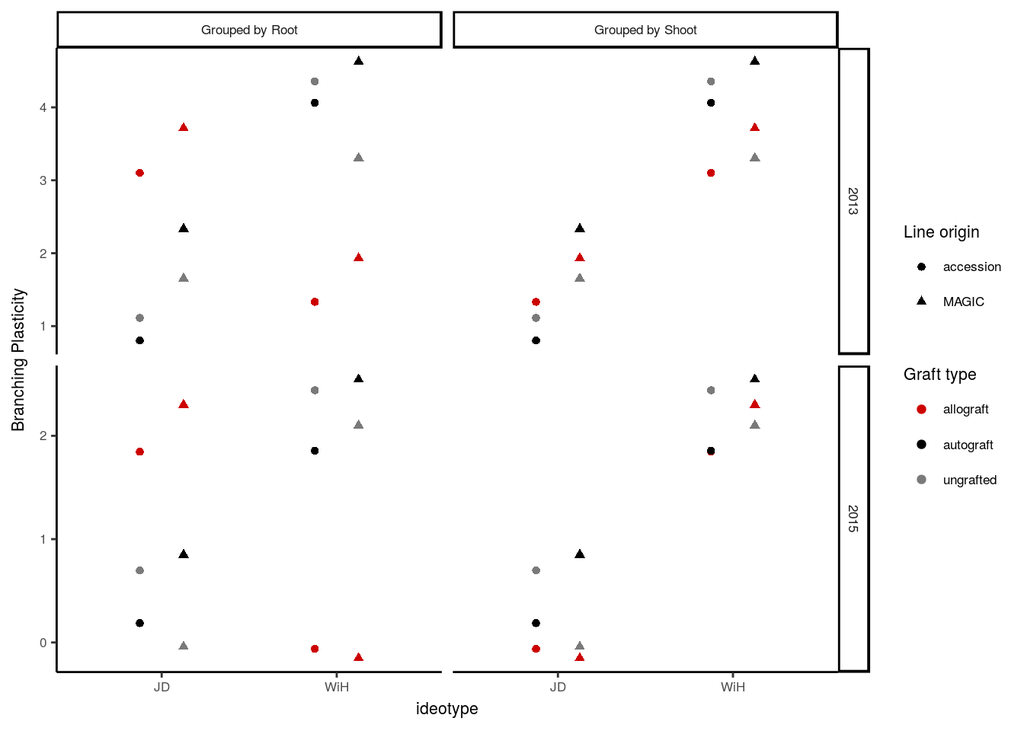

```r
graft %>%
  #mutate(root = ifelse(root_id == "non-grafted", shoot, root)) %>%
  group_by(id, shoot_id, root_id, shoot_type, root_type, graft_type, type, nitrate, experiment) %>%
  summarise(totalbr_mean = mean(totalbr)) %>%
  spread(nitrate, totalbr_mean) %>%
  mutate(D = HN-LN) %>%
  gather("part", "ideotype", shoot_type, root_type) %>%
  mutate(part = plyr::mapvalues(part, c("root_type", "shoot_type"), c("Grouped by Root", "Grouped by Shoot"))) %>%
  ggplot(aes(ideotype, D, colour = graft_type, group = type, shape = type)) +
  geom_point(position = position_dodge(0.5)) +
  labs(colour = "Graft type", y = "Branching Plasticity", shape = "Line origin") +
  scale_colour_manual(values = c("red3", "black", "gray48")) +
  facet_grid(experiment ~ part, scales = "free")
```

Just as a side note. In the plot showing the mean branching in each condition, it seems like there’s an interaction between nitrate response and experiment (the slopes of the lines are not the same between experiments). This can be captured by a more complex model, which suffers from many parameters to estimate, so the degrees of freedom used are higher. Just for completeness, though, it’s shown here that the conclusions are qualitatively the same:

```r
# Note: fitting by ML fails
lmm3 <- lmer(totalbr ~ nitrate*shoot_type + nitrate*root_type +
               experiment + (nitrate:experiment|id),
             data = graft, REML = TRUE)
car::Anova(lmm3, test.statistic = "F")
```

```
## Analysis of Deviance Table (Type II Wald F tests with Kenward-Roger df)
##
## Response: totalbr
##                           F Df  Df.res    Pr(>F)
## nitrate            162.7650  1  8.9843 4.638e-07 ***
## shoot_type          24.3288  1  9.5058 0.0006898 ***
## root_type            2.7006  1  9.4784 0.1330180
## experiment           3.6957  1 10.9915 0.0808392 .
## nitrate:shoot_type  51.4104  1  9.4912 3.988e-05 ***
## nitrate:root_type    0.0062  1  9.4700 0.9387926
## ---
## Signif. codes:  0 '***' 0.001 '**' 0.01 '*' 0.05 '.' 0.1 ' ' 1
```

In this case, the marginal effect of experiment is not significant, as it is probably captured by the variance attributed to it in the random part of the model.

## Effect of root and shoot ideotypes on flowering time

We follow the same logic as above for shoot branching.

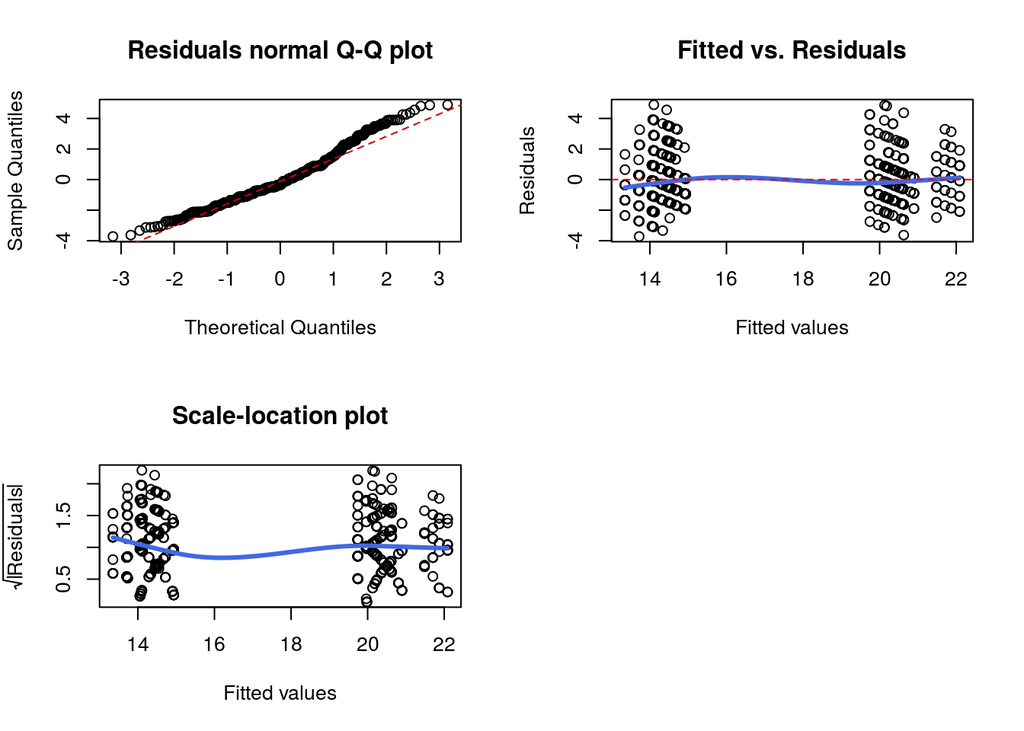

```r
bolt_lmm1 <- lmer(days_to_bolt ~ nitrate*shoot_type + nitrate*root_type +
                    experiment + (nitrate|id),
                  data = graft, REML = FALSE)
plotLmmDiag(bolt_lmm1)
```

Due to the way in which the genotypes were chosen (to fit within JD and WiH ideotypes), the distribution of flowering times is rather bimodal. The residuals are not as good as for branching, but it still looks OK, with no obvious heteroskedasticity between the two groups from the scale-location plots.

We start by analysing the variance from the model:

```r
car::Anova(update(bolt_lmm1, REML = TRUE), test.statistic = "F")
```

```
## Analysis of Deviance Table (Type II Wald F tests with Kenward-Roger df)
##
## Response: days_to_bolt
##                           F Df Df.res    Pr(>F)
## nitrate              3.4426  1   8.86  0.097053 .
## shoot_type         263.9561  1   9.10 4.966e-08 ***
## root_type            0.9914  1   9.09  0.345173
## experiment           8.4737  1 603.63  0.003736 **
## nitrate:shoot_type   0.3098  1   9.41  0.590784
## nitrate:root_type    0.2979  1   9.45  0.597862
## ---
## Signif. codes:  0 '***' 0.001 '**' 0.01 '*' 0.05 '.' 0.1 ' ' 1
```

As before, there is a very large F-value for `shoot_type`, although now the interaction doesn’t have that high value. Nitrate is also expected to have less of an effect, which is also illustrated by the comparatively lower F-value.

We start by testing the overall effect of roots with likelihood-ratio test:

```r
# Remove the root effects (root and root x nitrate)
anova(update(bolt_lmm1, . ~ . - nitrate*root_type), bolt_lmm1) %>% tidy()
```

```
##                                             term df      AIC      BIC
## 1 update(bolt_lmm1, . ~ . - nitrate * root_type)  9 2388.158 2428.025
## 2                                      bolt_lmm1 11 2390.652 2439.378
##      logLik deviance statistic Chi.Df   p.value
## 1 -1185.079 2370.158        NA     NA        NA
## 2 -1184.326 2368.652  1.506432      2 0.4708498
```

It does not seem significant.

Let’s consider the shoot type:

```r
# Remove the root effects (root and root x nitrate)
anova(update(bolt_lmm1, . ~ . - nitrate*shoot_type), bolt_lmm1) %>% tidy()
```

```
##                                              term df      AIC      BIC
## 1 update(bolt_lmm1, . ~ . - nitrate * shoot_type)  9 2427.719 2467.587
## 2                                       bolt_lmm1 11 2390.652 2439.378
##      logLik deviance statistic Chi.Df      p.value
## 1 -1204.860 2409.719        NA     NA           NA
## 2 -1184.326 2368.652  41.06764      2 1.208581e-09
```

This is significant. We should now consider if the interaction itself seems significant (we expect not, given the lack of plasticity for flowering):

```r
anova(update(bolt_lmm1, . ~ . - nitrate:shoot_type), bolt_lmm1) %>% tidy()
```

```
##                                            term df      AIC      BIC
## 1 update(bolt_lmm1, . ~ . - nitrate:shoot_type) 10 2388.983 2433.280
## 2                                     bolt_lmm1 11 2390.652 2439.378
##      logLik deviance statistic Chi.Df   p.value
## 1 -1184.491 2368.983        NA     NA        NA
## 2 -1184.326 2368.652 0.3314127      1 0.5648284
```

Indeed, this interaction seems not significant. So we end up with a reduced model, which excludes root_type altogether, as well was the Shoot x Nitrate interaction:

```r
bolt_lmm2 <- lmer(days_to_bolt ~ nitrate + shoot_type + experiment + (nitrate|id),
                  data = graft)
summary(bolt_lmm2)
```

```
## Linear mixed model fit by REML ['lmerMod']
## Formula: days_to_bolt ~ nitrate + shoot_type + experiment + (nitrate |
##     id)
##    Data: graft
##
## REML criterion at convergence: 2377.4
##
## Scaled residuals:
##     Min      1Q  Median      3Q     Max
## -2.3637 -0.6619 -0.1913  0.5292  3.0622
##
## Random effects:
##  Groups   Name        Variance Std.Dev. Corr
##  id       (Intercept) 0.30661  0.55373
##           nitrateLN   0.00167  0.04086  1.00
##  Residual             2.59573  1.61113
## Number of obs: 620, groups:  id, 12
##
## Fixed effects:
##                Estimate Std. Error t value
## (Intercept)     14.3170     0.2654   53.94
## nitrateLN        0.2512     0.1304    1.93
## shoot_typeWiH    6.2836     0.3550   17.70
## experiment2015  -0.3798     0.1306   -2.91
##
## Correlation of Fixed Effects:
##             (Intr) ntrtLN sht_WH
## nitrateLN   -0.195
## shoot_typWH -0.670 -0.008
## exprmnt2015 -0.277  0.047  0.021
```

```r
car::Anova(bolt_lmm2, test.statistic = "F")
```

```
## Analysis of Deviance Table (Type II Wald F tests with Kenward-Roger df)
##
## Response: days_to_bolt
##                   F Df Df.res    Pr(>F)
## nitrate      3.6787  1  10.82  0.081864 .
## shoot_type 260.6719  1  10.00 1.727e-08 ***
## experiment   8.4098  1 604.49  0.003868 **
## ---
## Signif. codes:  0 '***' 0.001 '**' 0.01 '*' 0.05 '.' 0.1 ' ' 1
```

As before for shoot branching, root ideotype does not explain much variance in flowering time, whereas the shoot ideotype does.

Again, the shoot phenotype predict flowering time quite well:

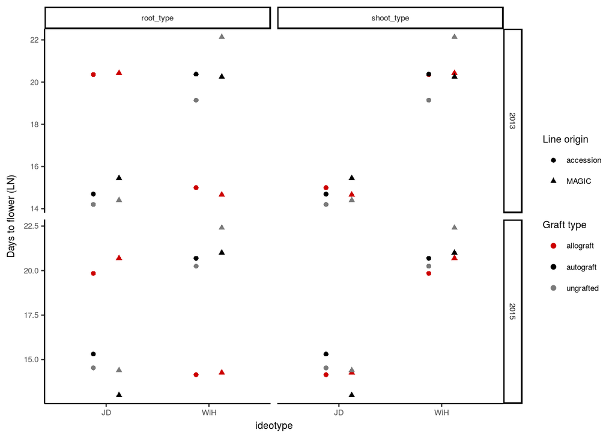

```r
graft %>%
  #mutate(root = ifelse(root_id == "non-grafted", shoot, root)) %>%
  group_by(id, shoot_id, root_id, shoot_type, root_type, graft_type, type, nitrate, experiment) %>%
  summarise(bolt_mean = mean(days_to_bolt)) %>%
  spread(nitrate, bolt_mean) %>%
  gather("part", "ideotype", shoot_type, root_type) %>%
  ggplot(aes(ideotype, LN, colour = graft_type, group = type, shape = type)) +
  geom_point(position = position_dodge(0.5)) +
  labs(colour = "Graft type", y = "Days to flower (LN)", shape = "Line origin") +
  scale_colour_manual(values = c("red3", "black", "gray48")) +
  facet_grid(experiment ~ part, scales = "free")
```